# Biweekly Progress Report 5

# Jacob Tiede

## Image Segmentation

This week I am hoping to round out my image processing toolkit by learning how to perform image segmentation. I want to get an idea of the cutting edge in this field, so I'm going to dive straight in to a paper from 2019 that details so-called Gated-SCNNs (found here: https://arxiv.org/pdf/1907.05740.pdf). First, I think it is pertinent to explicitly define what image segmentation is:

### What is Image Segmentation

I will use https://ai.stanford.edu/~syyeung/cvweb/tutorial3.html as a guide, though much of this document is methods of segmentation not related to deep learning, which I will gloss over. In general, image segmentation involves assigning a class label to each pixel in an image. Making this more rigorous: given an image tensor $X$ made of pixels $x_{c,i,j}$ we would like to assign each pixel a class (and color) if that pixel is a part of a greater image. For instance, if pixel $x_{:,1,1}$ is a part of a person then we might assign it to class 1, where as if pixel $x_{:,100,100}$ is a part of a building we might assign it to class 2. This gives a sort of simplification of the image that conveys similar information without the details. To make this salient consider assigning each class a color. If we were to create a new image where each pixel is colored based on its class's color then we would have a much simpler image, but it would still be obviously the same information. The rest of the article is methods for doing this image segmentation, none of which make use of deep learning, though it is worth noting that there are less complex ways of accomplishing this task (namely various forms of clustering). Now that we have a good idea of what the problem is we can move on to the paper.

### What Problem does this Paper Seek to Solve

The authors identify that one problem with prior segmentation algorithms is that information from the image is "dense" meaning it incorporates many aspects that are all relevant to what we are seeing, like color, texture, and shape. This presents a complex problem that the authors seek to simplify by breaking the image processing into two streams: a "shape" stream and a "classical" stream. I will detail what each of these are later, but suffice to say that this paper is simplifying segmentation by taking the original image and trying to tease out some information in one steam of the model, and using a second stream to get the rest of the information. But why is this useful? Traditional segmentation algorithms tend to be less accurate around the boundary, so separating information pertaining to the boundary of segments could potentially solve this problem. With a broad idea of what we are looking to solve in hand, we can start talking about background information:

### Necessary Background

#### Multitask Learning

For this section I will summarize this article on the topic of multitask learning: https://towardsdatascience.com/multitask-learning-teach-your-ai-more-to-make-it-better-dde116c2cd40. Multitask learning is simply asking the same neural net to solve multiple problems. For instance, one might ask a neural net to both classify an object as well as draw a bounding box around it. There are certainly some shared aspects about each of these tasks, so the logic is that we will have a number of shared layers followed by a small set of task specific layers for each of the given tasks. This means that we learn a set of parameters that can solve both tasks, which means that the final set of parameters that the shared layer has learned is necessarily more generalizable. One can think of this as having a regularizing effect on the shared layers which makes both of the nets work more effectively on a validation set. In fact, the article talks about how lasso and ridge regression are both examples of multitask learning in a way, which are both well known methods of regularization as well, so this connection should seem quite natural. This is really all there is to multitask learning (of course without all of the subtlety that comes in application, but from a conceptual standpoint it is a fairly brief concept). Our paper will not apply this idea exactly, instead they will make use of the general idea to solve a problem that is very closely related to the problem of segmentation in addition to the segmentation itself (rather than solving multiple more disperate problems simultaneously), but we'll get to that in a later section.

#### Gated Convolutions

For this section I will summarize https://arxiv.org/pdf/1612.08083.pdf to learn more about gated convolutions. The problem this paper sought to solve was the inherently non-parallelizable nature of recurrent neural networks. Convolutions had been used in the past to try and remedy this problem, but had never achieved state-of-the-art accuracy for NLP tasks. This paper contributes to the literature by introducing a parallelizable architecture for solving NLP problems in the form of gated convolutions. Gated convolutions can be summarized by the following figure from the paper:

[figure not shown]

Basically the flow of a gated convolution is to first translate a sentence (a sequence of words denoted $w_{i}$ in the figure) into their embeddings (they use a lookup table to do this, though these embeddings could in theory be learned). Using the notation from the paper this step is mathematically called $E = D_{w_i}$. Now we get to what a gated convolution really is. First a single convolution with parameters $W$ and $b$ is applied to the embedded sentence vector which gives and output $A$. A second convolution (this will serve as the "gating" convolution) with parameters $V$ and $c$ is then also applied to $E$ and gives an output $B$. The gating step then involves taking the sigmoid of $B$ and pointwise multiplying it with $A$. There is also the possibility to add a residual skip connection between the input of this gated convolution and this output $A*\sigma(B)$ (see this article for more details https://towardsdatascience.com/how-to-build-a-gated-convolutional-neural-network-gcnn-for-natural-language-processing-nlp-5ba3ee730bfb). These outputs can then be "stacked" to give accurate hidden representations of the sentence to be used in classification. It's worth noting that this sequence is zero padded at the start of the sentence in order to prevent our model from accessing information from future parts of the sentence (at any given time step it can only process words that have already been spoken). Of course our paper will need to make some adjustments to this idea (since it was used in NLP instead of image processing), but it is good to keep this idea in mind when we talk about how to implement this idea for image segmentation.

#### Atrous Convolution

For this section I will quickly summarize the high points of https://arxiv.org/pdf/1606.00915.pdf, which details a new kind of convolution: Atrous Convolutions. This is a fairly simple concept, but it is wildly important for segmentation tasks. Basically, it spaces out the points of the kernel (that would normally be applied densely along a square of size $kXk$ where k is the kernel size. In an Atrous convolution this kernel is applied sparsely along a larger grid. Here's a good picture of what's happening in two dimension that can be found here: https://github.com/vdumoulin/conv_arithmetic/blob/master/README.md:

[figure not shown]

As the authors of this paper state, this has the effect of enlarging the field of view of the output tensor without increasing the number of parameters.

#### Atrous Spatial Pyramid Pooling

For this section I will again use https://arxiv.org/pdf/1606.00915.pdf as a guide. Atrous Spatial Pyramid Pooling simply refers to applying multiple Atrous Convolutions of different dilation sizes to the same input used to create feature maps which incorporate information from multiple resolution scales. In this original inception of spatial pyramid pooling (not atrous) pooling operations were used at different scales just before the flattening step in predictive algorithms (see https://medium.com/coinmonks/review-sppnet-1st-runner-up-object-detection-2nd-runner-up-image-classification-in-ilsvrc-906da3753679 for more details). In our case it will be used to merge multiple information representations together. A picture of this found in the paper is:

[figure not shown]

### An Overview of the Model

As I said before this paper will employ a multi stream model (specifically we will have two streams), one as a "regular" stream and the other as a "shape" stream. The regular stream is largely responsible for making sure the segments are broadly correct (sort of replicating what has already been done in segmentation research), and the other stream is responsible for making the borders of class segments correct. These are then synthesized together to give the image segmentation. The first stream is structured in a fairly conventional way as far as prior segmentation models go (I will explain this in more detail in a later section), but what is less obvious is how we enforce that the shape stream is only seeing the shape of the objects (the boundaries). Without getting into the details (yet) the shape stream will use the output of the first convolution in the regular stream, and the image gradients as the input and the goal is for it to output the boundaries of the semantic segmentation. To isolate the semantic boundaries the neural net will use residual blocks (which have been a theme throughout most image processing problems I have implemented), as well as gated convolutions. These gated convolutions are actually where the authors enforce that this branch is only considering the semantic boundaries, and since the explanation is somewhat non-obvious for this I will leave it for a subsequent section. The final macro part of the model is the "fusion module" this will take the information from both streams of the model and synthesize them together. It does this by using an Atrous Spatial Pyramid Pooling layer so that information from all resolution scales is preserved. With that in mind we can start to talk about the details of this model:

### Getting into the Details

For this section I wanted to include a picture of what we were talking about to keep in mind. This is figure 2 from the paper and it illustrates many of the important aspects of this architecture:

[figure not shown]

#### The Regular Stream

This one is left fairly open as far as architecture decisions are concerned. This can be any feedforward convolutional net, though the authors opt for a ResNet-101 like structure.

#### The Shape Stream

As stated before this will take the output of the first convolutional layer of the regular stream and the image gradients as inputs. As a quick aside image gradients are something that is calculated based on the original image, and is defined as (this equation comes from https://lilianweng.github.io/lil-log/2017/10/29/object-recognition-for-dummies-part-1.html#image-gradient-vector): $$ \begin{align*} \nabla f(x, y) = \begin{bmatrix} g_x \\ g_y \end{bmatrix} = \begin{bmatrix} \frac{\partial f}{\partial x} \\[6pt] \frac{\partial f}{\partial y} \end{bmatrix} = \begin{bmatrix} f(x+1, y) - f(x-1, y)\\ f(x, y+1) - f(x, y-1) \end{bmatrix} \end{align*} $$ Where $f$ is a 2D image matrix. More details on this can be found here: https://lilianweng.github.io/lil-log/2017/10/29/object-recognition-for-dummies-part-1.html#image-gradient-vector. Now, moving back to the paper, the authors state that the input from the regular stream is processed using several residual blocks along with gated convolutions which are designed to enforce that this stream is only looking at shapes. It's worth going into this block in a little more depth now:

##### Gated Convolutions in the Shape Stream

Intuitively, this will use an attention mask (much like that of TabNet from my second biweekly report) to determine which features are relevant for this stream. It does this by taking an intermediate layer of the regular stream and concatenating it with the output of one of the residual blocks of the shape stream. A 1x1 convolution is then applied, the output of which is passed through a sigmoid. This will produce a mask $\alpha$ of the same dimension as the input. Summarizing this using symbols: $$ \alpha = \sigma(C_{1x1}(s_t||r_t)) $$ Where $s_t$ is the output of one of the residual blocks in the shape stream, $r_t$ an intermediate tensor in the regular stream, and $||$ is channelwise concatenation. This mask is then pointwise multiplied with $s_t$ and passed through a "channelwise weighting with kernel" layer (which, looking through their source code to find what this meant, appears to just be another convolution layer). So every gating layer creates a mask, multiplies it pointwise with the variable that we are gating, and applies another convolution to it. Also, $s_t$ and $r_t$ need not be the same size since the authors simply apply bilinear interpolation if there is a conflict in sizes.

#### Multi-Task Learning

This is where the fusion module comes into play. We would like to learn both how to do edge detection and segmentation at the same time with this model. As we said before the information from the two streams is combined in an Atrous Spatial Pyramid Pooling layer. This then gives a representation that can be compared to ground truth representations using simple binary cross entropy.

#### Other Details

There are other details for this implementation, but they rely much more heavily on background knowledge from image processing. Since this is my first attempt at doing segmentation I think it would be best to skip those details (like the specific regularizations they do) for now. I don't want to depend on my being able to get all of those background details without first implementing the pure deep learning aspects. To this end I will focus on just implementing what I've explained above. Also, it's worth noting that in the source code the authors state they used 4 GPUs to train this, which I certainly do not have access to, so my results will almost certainly vary.

### Implementation:

#### EDA

To start we'll take a look at the dataset we will use found here: https://www2.eecs.berkeley.edu/Research/Projects/CS/vision/grouping/resources.html#bsds500.

```python
import torch
import torch.nn as nn
import torch.nn.functional as F
import pandas as pd
import numpy as np
import time
from sklearn.metrics import accuracy_score
import matplotlib.pyplot as plt
from PIL import Image
import torchvision.transforms.functional as TF
import torchvision
import os
import matplotlib.pyplot as plt
import progressbar #If you're missing this library it is found here: https://pypi.org/project/progressbar2/
print("Is a GPU available? ")
torch.cuda.is_available()
```

```
Is a GPU available?
```

```
True
```

To start, I think it's important to see what these files actually are since I haven't used .mat in python before:

```python
import scipy.io
mat = scipy.io.loadmat('./Data/BSR/BSDS500/data/groundTruth/train/100075.mat')
```

```python
mat.keys()
```

```
dict_keys(['__header__', '__version__', '__globals__', 'groundTruth'])
```

It looks like the output of this read is a dictionary, but we are mostly interested in the "groundTruth" key:

```python
print("The shape of the ground truth array is:")
mat['groundTruth'].shape
```

```
The shape of the ground truth array is:
```

```
(1, 6)
```

```python
print("The shape of the segmentation mask:")
mat['groundTruth'][0,0][0][0][0].shape
```

```
The shape of the segmentation mask:
```

```
(321, 481)
```

```python
print("The shape of the edge ground truth:")
mat['groundTruth'][0,0][0][0][1].shape
```

```
The shape of the edge ground truth:
```

```
(321, 481)
```

```python
def showImage(x):
    img = x.detach().cpu().numpy()
    plt.imshow(np.transpose(img, (1,2,0)), interpolation='nearest')
    plt.show()
#Want a method that shows the segmentation mask. Since these class labels are outside of the normal range of an image we will need to assign each a color:
def showSegmentation(x):
    color = {}
    for i in np.unique(x):

        r = torch.rand(1,3)
        color[i] = r

    temp = torch.zeros(3, x.shape[0], x.shape[1])

    for i in range(x.shape[0]):
        for j in range(x.shape[1]):
            temp[:,i,j] = color[x[i,j]]
    showImage(temp)
```

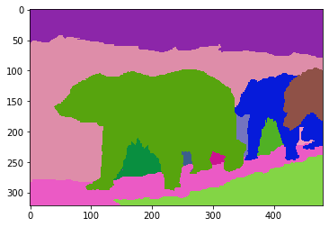

```python
showSegmentation(mat['groundTruth'][0,0][0][0][0])
```

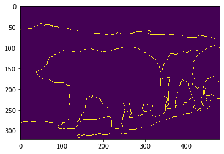

```python
#let's see what an edge image looks like
def showEdge(x):
    img = x.detach().cpu().numpy()
    plt.imshow(img, interpolation='nearest')
showEdge(torch.from_numpy(mat['groundTruth'][0,0][0][0][1]))
```

Looks good, now let's try to load the complete dataset, copy some code from last week, except this time we are going to simply crop the image since a bilinear interpolation to a smaller resulution would change the segmentation map in a way taht would make it impossible to translate it to the class names:

```python
#Using code from last week's biweekly report to load in the data:
import torchvision.transforms as transforms
#Load the data into python:

#The data is all in separate files, so we will need a way of reading a single jpg, appending it to our running tensor of data, and
#then reading another file
def loadData(folderName):
    i = 0
    imSize = 256
    #For more info on how to use progress bar: https://pypi.org/project/progressbar2/
    numImages = len([name for name in os.listdir(folderName)])
    with progressbar.ProgressBar(max_value=numImages) as bar:
        #iterate through each file in a directory, code adapted from:
        #https://stackoverflow.com/questions/10377998/how-can-i-iterate-over-files-in-a-given-directory
        for file in os.listdir(folderName):
            if file.endswith(".jpg"):
                #read an image into pytorch: https://discuss.pytorch.org/t/how-to-read-just-one-pic/17434/2
                image = Image.open(os.path.join(folderName, file))
                transformer = transforms.Compose([transforms.ToTensor()])
                x = transformer(image)
                x.unsqueeze_(0)
                if i == 0:
                    out = torch.zeros(numImages, x.shape[1], imSize, imSize)
                    out[i,:,:,:] = x[:,:, 0:imSize, 0:imSize]
                    i+=1
                else:
                    out[i,:,:,:] = x[:,:, 0:imSize, 0:imSize]
                    i+=1
                bar.update(i)
    return out
trainData = loadData("./Data/BSR/BSDS500/data/images/train")
```

```
100% (202 of 202) |######################| Elapsed Time: 0:00:00 Time:  0:00:00
```

```python
trainData[0].shape
```

```
torch.Size([3, 256, 256])
```

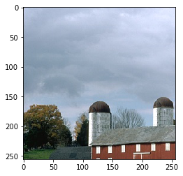

```python
showImage(trainData[199,:,:,:])
```

```python
def loadTarget(folderName):
    i = 0
    imSize = 256
    #For more info on how to use progress bar: https://pypi.org/project/progressbar2/
    numImages = len([name for name in os.listdir(folderName)])
    with progressbar.ProgressBar(max_value=numImages) as bar:
        #iterate through each file in a directory, code adapted from:
        #https://stackoverflow.com/questions/10377998/how-can-i-iterate-over-files-in-a-given-directory
        for file in os.listdir(folderName):
            if file.endswith(".mat"):
                #read an image into pytorch: https://discuss.pytorch.org/t/how-to-read-just-one-pic/17434/2
                image = scipy.io.loadmat(os.path.join(folderName, file))['groundTruth'][0,0][0][0]
                seg = torch.from_numpy(image[0].astype('float32'))
                edge = torch.from_numpy(image[1].astype('float32'))
                if i == 0:
                    segmentations = torch.zeros(numImages, imSize, imSize)
                    segmentations[i,:,:] = seg[0:imSize, 0:imSize]
                    edges = torch.zeros(numImages, imSize, imSize)
                    edges[i,:,:] = edge[0:imSize, 0:imSize]
                    i+=1
                else:
                    segmentations[i,:,:] = seg[0:imSize, 0:imSize]
                    edges[i,:,:] = edge[0:imSize, 0:imSize]
                    i+=1
                bar.update(i)
    return segmentations, edges

segmentations, edges = loadTarget('./Data/BSR/BSDS500/data/groundTruth/train')
```

```
100% (200 of 200) |######################| Elapsed Time: 0:00:01 Time:  0:00:01
```

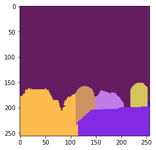

```python
showSegmentation(segmentations[199,:,:].numpy())
```

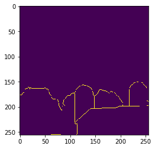

```python
showEdge(edges[199,:,:])
```

```python
#looks like there are two more images in the training set than there are in the edge/segmentation set. I manually looked to verify that all of the images prior
#to these two aligned, and it looks like two images are just extraniously in the train data images file. Removing these:
trainData = trainData[0:edges.shape[0],:,:,:]
print(trainData.shape)
```

```
torch.Size([200, 3, 256, 256])
```

Now let's take a look at what we are dealing with, starting with looking at how many segmentation classes exist on the segmentation masks:

```python
uniqueClasses = []
for i in range(segmentations.shape[0]):
    for j in np.unique(segmentations[i,:,:].numpy()):
        if j not in uniqueClasses:
            uniqueClasses.append(j)
print("The number of classes in the segmentation classes is: ")
print(len(uniqueClasses))
print("The max class number:")
print(np.max(uniqueClasses))
```

```
The number of classes in the segmentation classes is:
74
The max class number:
80.0
```

This is a ton of classes (certainly more than anything I've delt with before). Let's take a step back and see how much data is in this data set:

```python
print("There are " + str(segmentations.shape[0]) + " entries in this data.")
```

```
There are 200 entries in this data.
```

This might actually be too small to work with effectively, though if this is unsuccessful we can certainly use a different dataset like the one found here: https://groups.csail.mit.edu/vision/datasets/ADE20K/, but I'm going to try and avoid this for now since I'm trying to avoid going over my internet provider's data cap. Similar to my previous week's image EDA we will look at average images, and histograms:

```python
#start by printing the mean segmentation mask.
avgSeg = torch.zeros(segmentations.shape[1], segmentations.shape[2])
for i in range(segmentations.shape[1]):
    for j in range(segmentations.shape[2]):
        avgSeg[i,j] = torch.mean(segmentations[:,i,j])
print("The average class value is: " + str(torch.mean(avgSeg)))
print("The standard deviation of the average pixel classes in the segmentation mask is: " + str(torch.std(avgSeg)))
```

```
The average class value is: tensor(4.6067)
The standard deviation of the average pixel classes in the segmentation mask is: tensor(2.4067)
```

That standard deviation is actually fairly high, let's see what we get if we round each pixel value to it's closest class to see if there's any consistant values in any region.

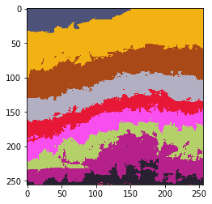

```python
showSegmentation(torch.round(avgSeg).numpy())
```

This is actually pretty interesting. These sort of "level bands" are most likely a result of different elevations of the images having different classes. For instance, the average class of the top most layer is probably "sky" for almost all of them. Then there's probably a band for mountains or background. You can see that as you move further down in the image the bands look less defined which is most likely a result of most of the objects in an image being situated toward the center, and probably lower down. This is certainly a bias in the data, and I wonder if the model will overfit to some of these trends. Now let's look at the average edge plot:

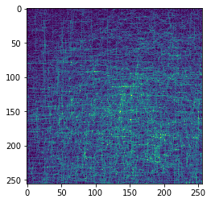

```python
avgEdge = torch.zeros(edges.shape[1], edges.shape[2])
for i in range(edges.shape[1]):
    for j in range(edges.shape[2]):
        avgEdge[i,j] = torch.mean(edges[:,i,j])
showEdge(avgEdge)
```

As our other plot sort of suggested you can see that a lot of the edges appear to be concentrated toward the middle of the image with less relavent edges toward the upper part of the images (we see especially low densities in the upper left). Finally, let's take a look at the average input image:

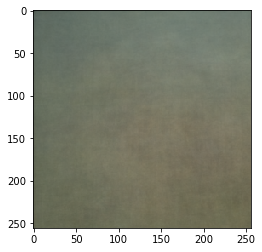

```python
avgIm = torch.zeros(trainData.shape[1],trainData.shape[2],trainData.shape[3])
for i in range(trainData.shape[2]):
    for j in range(trainData.shape[3]):
        avgIm[:,i,j] = torch.mean(trainData[:,:,i,j], dim = 0)
showImage(avgIm)
```

There are some slight regularities, but nothing that look too strange. I think the take away from these average images that I have been using is that for complex image data (ie data from actual pictures rather than simplified segmenatation/edge maps) it is really had to see any regularities using just a simple average (despite there being some clear trends when we look at other simplified representations). Next, let's take a look at the the channel-wise histograms for this input images (I'll reuse some code from my previous biweekly report):

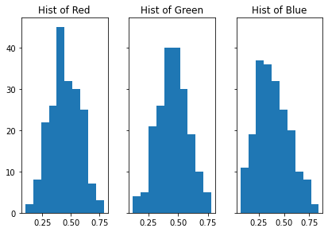

```python
def colorHist(x):
    #keep track of average values for RGB channels
    R = []
    G = []
    B = []
    for i in range(3):
        temp = []
        for j in range(x.shape[0]):
            temp.append(torch.mean(x[j,i,:,:]))
        if i == 0:
            R = np.array(temp)
        elif i == 1:
            G = np.array(temp)
        else:
            B = np.array(temp)
    fig, (ax1, ax2, ax3) = plt.subplots(1, 3,sharey=True)
    fig.tight_layout()

    ax1.hist(R)
    ax1.set_title("Hist of Red")
    ax2.hist(G)
    ax2.set_title("Hist of Green")
    ax3.hist(B)
    ax3.set_title("Hist of Blue")
colorHist(trainData)
```

This looks to be very slightly skewed to the left for the green and red color channels. It might just be a good idea to normalize these images regardless:

```python
for i in range(trainData.shape[2]):
    for j in range(trainData.shape[3]):
        trainData[:,:,i,j] = (trainData[:,:,i,j] - torch.mean(trainData[:,:,i,j], dim = 0))/(torch.std(trainData[:,:,i,j], dim = 0))
        #min max scaling to rescale it to [0,1]:
        minima = torch.min(trainData[:,:,i,j])
        maxima = torch.max(trainData[:,:,i,j])
        trainData[:,:,i,j] = (trainData[:,:,i,j]-minima)/(maxima-minima)*(1-0)+0
```

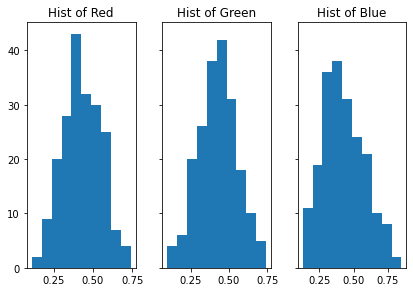

```python
colorHist(trainData)
```

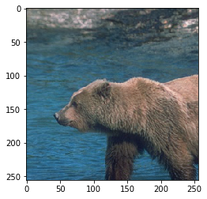

```python
showImage(trainData[0,:,:,:])
```

Our distribution looks almost exactly the same after this normalization, so it is likely that this was just normally distributed already. I think this EDA is sufficient, so we can now move on to implementing the neural net itself:

#### Implementing the Neural Net:

To start, it will help us to implement the two new functions first. Let's start with defining the gated convolution.

```python
"""
GatedConv - Implements a gated convolution block as described by https://arxiv.org/pdf/1612.08083.pdf with modifications from https://arxiv.org/pdf/1907.05740.pdf

@Params - c_in: input channels
          c_s: number of channels in the 1x1 convolution
          c_out: number of channels in the output
"""
class GatedConv(nn.Module):
    def __init__(self, c_in, c_s, c_out):
        super(GatedConv, self).__init__()
        self.c_in = c_in
        self.c_s = c_s
        self.c_out = c_out

        self.path1 = nn.Conv2d(self.c_in, self.c_s, 1)
        self.path_out = nn.Conv2d(self.c_s*2, self.c_out, 1)

    def forward(self, x, y):
        assert x.shape[1]+y.shape[1] == self.c_in, "Input not constructed correctly to GatedConv shape of cated input: " + str(x.shape[1]+y.shape[1]) + str("expected shape: ") + str(self.c_in)
        assert self.c_s == x.shape[1], "Shape stream input with the wrong number of channels"
        assert x.shape[2] == y.shape[2] and x.shape[3] == y.shape[3], "Cannot gate tensors, resolutions are different"

        catVar = torch.cat((x,y), dim = 1)

        gate = torch.sigmoid(self.path1(catVar))

        gate = x*gate
        x = self.path_out(torch.cat((gate,x), dim = 1))
        return x
#test that this works:
x = torch.rand(1,3,10,10).cuda()
y = torch.rand(1,6,10,10).cuda()

gated = GatedConv(9, 3, 4).cuda()
#forward prop:
out = gated(x,y)
print("Size of the output: " + str(out.shape))
loss = torch.mean(out)
#backward prop:
loss.backward()
print("Backward propagation carried out without incident")
```

```
Size of the output: torch.Size([1, 4, 10, 10])
Backward propagation carried out without incident
```

Now we can implement Atrous Spatial Pyramid Pooling:

```python
"""
ASPP - Implement Atrous Spatial Pyramid Pooling as described by: https://arxiv.org/pdf/1606.00915.pdf

#The implementation was non-obvious for me in this case (based solely on the description given in the paper), so I did look at the source code found here:
https://github.com/nv-tlabs/GSCNN/blob/master/network/gscnn.py

@params: c_in: number of input channels
         c_out: number of output channels in each conv in the spatial pooling
         resolutions: what dialation factor we should use
"""

class ASPP(nn.Module):
    def __init__(self, c_in, c_out = 64, resolutions  = [6,12,18]):
        super(ASPP, self).__init__()
        self.c_in = c_in
        self.c_out = c_out
        self.resolutions = resolutions

        self.poolings = nn.ModuleList([])
        #First pooling does not have dilation, but 0 is not a valid dilation constant, so much put this one in separately:
        self.poolings.append(nn.Sequential(nn.Conv2d(self.c_in, self.c_out, 1),
                                           nn.BatchNorm2d(self.c_out),
                                           nn.ReLU()))
        for i in self.resolutions:
            #Note: I don't think I've used the sequential functionality from pytorch in this class before, but I really should have. It allows us to define
            #a set of layers that the input will be passed through sequentially. For instance, here we will pass the input through a conv, then BN, then relu
            self.poolings.append(nn.Sequential(nn.Conv2d(self.c_in, self.c_out, 3, padding = i, dilation = i),
                                               nn.BatchNorm2d(self.c_out),
                                               nn.ReLU()))
        #This will be used as a way of processing the regular stream input
        self.adaptivePool_img = nn.AdaptiveAvgPool2d(1)
        #recall that we have two inputs to this part, one from the regular stream and one from the shape stream, we will also need to process.
        #This isn't detailed in the paper, but, judging by the source code, we will also be implementing a concatinated residual connection where each input
        #will be processed separately from the pyramid pooling, then concatinated in the output. This will become apparent in the implementation of the forward
        #pass

        self.conv_img = nn.Sequential(nn.Conv2d(self.c_in, self.c_out, 1),
                                      nn.BatchNorm2d(self.c_out),
                                      nn.ReLU())

        #Since the edge input will also be used in the loss (ie this input is the predicted edge detection mask) it will have a single channel
        self.conv_edge = nn.Sequential(nn.Conv2d(1, self.c_out, 1),
                                      nn.BatchNorm2d(self.c_out),
                                      nn.ReLU())

    #x is reg stream input, y is shape stream input
    def forward(self, x, y):
        temp_img = self.adaptivePool_img(x) #outputs (batch size, c_in, 1, 1)
        temp_img = self.conv_img(temp_img) #outputs (batch size, c_out, 1, 1)

        #Every time we would like to increase the resolution of an image in the process of training (like if the inputs to the gated conv are different)
        #This will be how the authors interpolate
        temp_img = F.interpolate(temp_img, (x.shape[2], x.shape[3]), mode = 'bilinear', align_corners = True) #outputs (batch_size, c_out, H, W)

        #our output will include temp_img
        output = temp_img

        #y (the output from the shape stream) potentially has a different size than the output from regular stream. Fix this with interpolation:
        temp_edge = F.interpolate(y, (x.shape[2], x.shape[3]), mode = 'bilinear', align_corners = True)
        #Now process y but with the correct shape:
        temp_edge = self.conv_edge(temp_edge)

        #This is a part of the output:
        output = torch.cat((output, temp_edge), dim = 1)

        #Now do the spatial pyramid pooling:
        for i in range(len(self.poolings)):
            temp = self.poolings[i](x)

            #This representation will be a part of the output:
            output = torch.cat((output, temp), dim = 1)
        return output

#Test this:
test_reg = torch.rand(4,64,10,10).cuda()
test_shape = torch.rand(4,1,40,40).cuda()

model = ASPP(64).cuda()

#forward pass
out = model(test_reg, test_shape)
print("The shape of the output is: " + str(out.shape))

#backward pass
loss = torch.mean(out)
loss.backward()
print("The backward pass was exicuted without incident")
```

```
The shape of the output is: torch.Size([4, 384, 10, 10])
The backward pass was exicuted without incident
```

Looks good, now we can implement the path of the full model:

```python
import cv2
"""
ResBlock - Define a residual block to be used in the Generator, note: these are addition res blocks, and will be used in the Shape stream

@params - n_in: the number of channels being fed into the ResBlock
        - n_out: the number of output channels of each convolution
        - n_layers: the number of layers in the resnet structure
"""
class ResBlock(nn.Module):
    def __init__(self, n_in, n_out, n_layers = 5):
        super(ResBlock, self).__init__()
        self.n_in = n_in
        self.n_out = n_out
        self.n_layers = n_layers

        self.convLayers = nn.ModuleList([])
        self.BNLayers = nn.ModuleList([])
        self.relu = nn.ReLU()
        self.convLayers.append(nn.Conv2d(self.n_in, self.n_out, 3, padding = 1))
        self.BNLayers.append(nn.BatchNorm2d(self.n_out))
        for i in range(self.n_layers-1):
            self.convLayers.append(nn.Conv2d(self.n_out, self.n_out, 3, padding = 1))
            self.BNLayers.append(nn.BatchNorm2d(self.n_out))
    def forward(self, x):
        for i in range(self.n_layers):
            if i != 0:
                x = x + x_mem
            x = self.BNLayers[i](self.relu(self.convLayers[i](x)))
            x_mem = x.clone()
        return x

"""
GSCNN - defines a gated shape CNN as described by https://arxiv.org/pdf/1907.05740.pdf

Some notes: The paper uses ResNet for the regular stream, I will use Sqeeze net to increase preformance

@params: num_classes: the number of classes we are trying to classify to
"""
import torchvision.models as models
class GSCNN(nn.Module):
    def __init__(self, num_classes):
        super(GSCNN, self).__init__()
        self.num_classes = num_classes
        #------------
        #The regular stream
        #------------

        #To get all of the layers as accessible objects I will follow the advice of this form:
        #https://discuss.pytorch.org/t/accessing-intermediate-layers-of-a-pretrained-network-forward/12113/2
        #This has 13 layers:
        self.squeezeNet = nn.ModuleList(list(models.squeezenet1_0(pretrained=True).features)) #Note: running an image through all of the layers will give an output of shape (batch,512,15,15)
        self.conv_reg_out = nn.Sequential(nn.Conv2d(512, 32, 1),
                                          nn.BatchNorm2d(32),
                                          nn.ReLU())
        #------------
        #The shape stream
        #------------

        #This will involve several resnet -> gated conv blocks
        #The ouput of the first layer of squuzenext will have 96 channels
        self.conv_1_shape = nn.Conv2d(96, 32, 1)

        #create the first res block:
        self.res_1 = ResBlock(32,32)

        #regular stream's 1x1 convolution before it is added to the gated conv:
        #Use 6th layer from squeeze net:
        self.conv_1_reg = nn.Sequential(nn.Conv2d(256, 32, 1),
                                        nn.BatchNorm2d(32),
                                        nn.ReLU())
        self.gated_1 = GatedConv(64, 32, 32)
        #next resblock
        self.res_2 = ResBlock(32,32)

        #Use 9th layer from squeeze net
        self.conv_2_reg = nn.Conv2d(384, 32, 1)
        self.gated_2 = GatedConv(64, 32, 32)

        #Last resblock
        self.res_3 = ResBlock(32,32)

        #Use Final layer from squeezenet
        self.conv_3_reg = nn.Conv2d(512,32, 1)
        self.gated_3 = GatedConv(64, 32, 32)

        #Need a final conv to get the shape channel into a single channel edge detection output:
        self.conv_final_shape = nn.Sequential(nn.Conv2d(32,1,1),
                                              nn.BatchNorm2d(1))

        #1x1 convolution for the concatinated shape stream output and image grads
        self.conv_cat = nn.Conv2d(2,1,1)
        #Put in the fusion module
        self.fusion = ASPP(32)

        #Looking through the source it looks like they do a little more processing of the fusion output
        self.conv_final_seg = nn.Sequential(nn.Conv2d(384, 64, 3, padding = 1),
                                            nn.BatchNorm2d(64),
                                            nn.ReLU(),
                                            nn.Conv2d(64,64,3, padding = 1),
                                            nn.BatchNorm2d(64),
                                            nn.ReLU(),
                                            nn.Conv2d(64, self.num_classes, 1))

    def forward(self, x):
        x_original_shape = x.shape

        #------------
        #Finding image gradients
        #Judging by the source code of the paper https://github.com/nv-tlabs/GSCNN/blob/master/network/gscnn.py they use a method called canny edge detection to
        #get image gradients. Copying the author's code here to do the same gradient detection:
        #------------
        im_arr = x.cpu().numpy().transpose((0,2,3,1)).astype(np.uint8)
        canny = np.zeros((x_original_shape[0], 1, x_original_shape[2], x_original_shape[3]))
        for i in range(x_original_shape[0]):
            canny[i] = cv2.Canny(im_arr[i],10,100)
        canny = torch.from_numpy(canny).cuda().float()

        #------------
        #The regular stream
        #------------
        gateLayers = []
        layersToSave = [0,5,8,12]
        for i, layer in enumerate(self.squeezeNet):
            x = layer(x)
            if i in layersToSave:
                gateLayers.append(x.clone())
        x = self.conv_reg_out(x)
        #------------
        #The shape stream
        #------------
        #Note that we want the input of this stream to be the same size as the image
        shape = self.conv_1_shape(F.interpolate(gateLayers[0], (x_original_shape[2], x_original_shape[3]), mode = 'bilinear', align_corners=True))

        shape = self.res_1(shape)

        #The first gate:
        #Need the tenor in gateLayers[1] to be of the correct shape:
        gate = F.interpolate(gateLayers[1], (x_original_shape[2], x_original_shape[3]), mode = 'bilinear', align_corners=True)
        gate = self.conv_1_reg(gate)
        shape = self.gated_1(shape, gate)
        shape = F.interpolate(shape, (x_original_shape[2], x_original_shape[3]), mode = 'bilinear', align_corners=True)

        shape = self.res_2(shape)


        #second gate
        gate = F.interpolate(gateLayers[2], (x_original_shape[2], x_original_shape[3]), mode = 'bilinear', align_corners=True)
        gate = self.conv_2_reg(gate)
        shape = self.gated_2(shape, gate)
        shape = F.interpolate(shape, (x_original_shape[2], x_original_shape[3]), mode = 'bilinear', align_corners=True)

        shape = self.res_2(shape)

        #final gate
        gate = F.interpolate(gateLayers[3], (x_original_shape[2], x_original_shape[3]), mode = 'bilinear', align_corners=True)
        gate = self.conv_3_reg(gate)
        shape = self.gated_3(shape, gate)
        shape = F.interpolate(shape, (x_original_shape[2], x_original_shape[3]), mode = 'bilinear', align_corners=True)

        #Get the edge output
        shape_out = torch.sigmoid(self.conv_final_shape(shape)) #BCE Loss will be applyed to this

        #Now we need to put the image gradients and the
        grad_edge_cat = torch.cat((canny, shape_out), dim = 1)
        grad_edge_cat = torch.sigmoid(self.conv_cat(grad_edge_cat))

        fusion_out = self.fusion(x, grad_edge_cat)

        seg_out= self.conv_final_seg(fusion_out)
        seg_out = F.interpolate(seg_out, (x_original_shape[2], x_original_shape[3]), mode = 'bilinear', align_corners=True)
        return seg_out, shape_out
#test
test = GSCNN(74).cuda()

seg, edge = test(trainData[0:2,:,:,:].cuda())
print("Segmentation output shape: " + str(seg.shape))
print("Edge detection output shape: " + str(edge.shape))
loss = torch.mean(seg) + torch.mean(edge)
loss.backward()
print("Back propagation exicuted without incident")
```

```
Segmentation output shape: torch.Size([2, 74, 256, 256])
Edge detection output shape: torch.Size([2, 1, 256, 256])
Back propagation exicuted without incident
```

```
The net's first attempt at image segmentation:
```

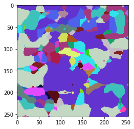

```python
seg = seg.cpu()
print("The net's first attempt at image segmentation: ")
showSegmentation(torch.argmax(seg[0,:,:,:], dim = 0).numpy())
```

```
The net's first attempt at edge detection:
```

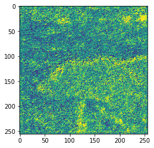

```python
edge = edge.cpu()
print("The net's first attempt at edge detection: ")
showEdge(edge[0,0,:,:])
del seg
del edge
torch.cuda.empty_cache()
```

Now we can implement the training loop, but first I want to quickly talk about the loss.

```
Loss for epoch 20 was 3.838855589279021
```

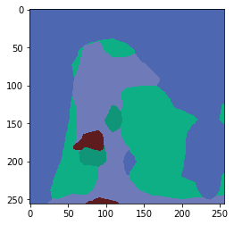

```
Loss for epoch 40 was 2.6324531345656426
```

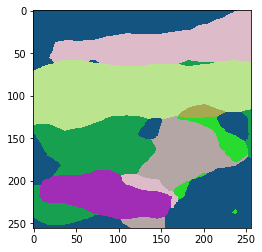

```
Loss for epoch 60 was 1.7508021948313472
```

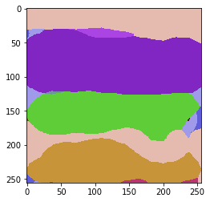

```
Loss for epoch 80 was 1.287283111100245
```

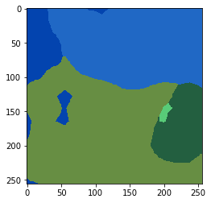

```
Loss for epoch 100 was 0.9249436749954416
```

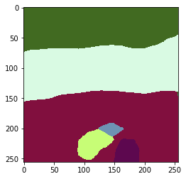

```
Loss for epoch 120 was 0.7319747974174191
```

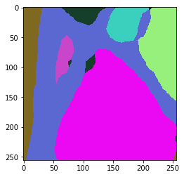

```
Loss for epoch 140 was 0.6028565306856175
```

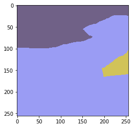

```
Loss for epoch 160 was 0.5006414922800931
```

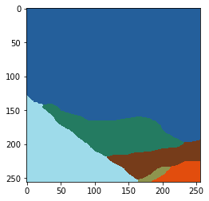

```
Loss for epoch 180 was 0.44482000999980503
```

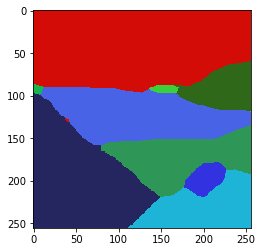

```
Loss for epoch 200 was 0.3983432614442074
```

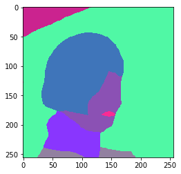

```python
model = GSCNN(81).cuda()

batch_size = 2
tot_epochs = 200
BCE = nn.BCELoss(reduction='none')
CE = nn.CrossEntropyLoss()
steps_per_epoch = int(np.floor(trainData.shape[0]/batch_size))
learning_rate = 1e-4
optimizer = torch.optim.Adam(model.parameters(), lr=learning_rate)
for i in range(tot_epochs):
    running_loss = 0

    #shuffle data
    temp = torch.randperm(trainData.shape[0])
    trainData = trainData[temp,:,:,:]
    segmentations = segmentations[temp,:,:]
    edges = edges[temp,:,:]
    for j in range(steps_per_epoch):
        optimizer.zero_grad()
        batch_x = trainData[j*batch_size:(j+1)*batch_size,:,:,:].cuda()
        batch_seg = segmentations[j*batch_size:(j+1)*batch_size,:,:].cuda()
        batch_edge = edges[j*batch_size:(j+1)*batch_size,:,:]

        #created weights for each edge example that weights them according to the scheme provided by https://arxiv.org/pdf/1504.06375.pdf
        weight = []
        for k in range(batch_edge.shape[0]):
            weights = torch.zeros(2)
            weights[1] = torch.sum(batch_edge[k,:,:])/(batch_edge.shape[1]*batch_edge.shape[2])
            weights[0] = 1-torch.sum(batch_edge[k,:,:])/(batch_edge.shape[1]*batch_edge.shape[2])
            weights = weights.cuda()
            weight.append(weights)

        batch_edge = batch_edge.view(batch_size, batch_edge.shape[1]*batch_edge.shape[2]).cuda()

        seg,edge = model(batch_x)

        edgeLoss = torch.tensor(0).cuda().float()
        l = 0
        #Used this as a reference: https://discuss.pytorch.org/t/unclear-about-weighted-bce-loss/21486
        for weights in weight:
            weight_ = weights[batch_edge.data.view(-1).long()].view_as(batch_edge)
            loss = BCE(edge[l,0,:,:].view(batch_edge.shape[1]).float(), batch_edge[l,:].float())
            loss = loss * weight_
            edgeLoss += torch.mean(loss)
            l+=1
        tot_loss = .5*edgeLoss + 2*CE(seg.float(), batch_seg.long())
        tot_loss.backward()
        optimizer.step()

        running_loss += tot_loss.item()
        torch.cuda.empty_cache()
        if j == steps_per_epoch-1 and i%20==19:
            print("Loss for epoch " + str(i+1) + " was " + str(running_loss/(steps_per_epoch)))
            showSegmentation(torch.argmax(seg.cpu()[0,:,:,:], dim = 0).numpy())
```

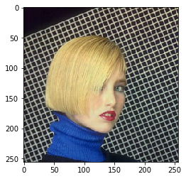

```python
showImage(batch_x[0,:,:,:])
```

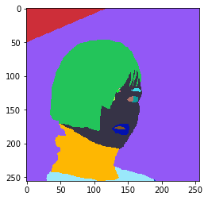

```python
showSegmentation(batch_seg[0,:,:].cpu().numpy())
```

Those are some great results qualatatively. I do, however, wonder if we might have overfit to the training set (since we did see some clear bias in the training data), so let's take a look at this model evaluated on on image from the test set:

```python
testData = trainData = loadData("./Data/BSR/BSDS500/data/images/test")
segmentationsTest, _ = loadTarget('./Data/BSR/BSDS500/data/groundTruth/test')
```

```
100% (201 of 201) |######################| Elapsed Time: 0:00:00 Time:  0:00:00
100% (200 of 200) |######################| Elapsed Time: 0:00:01 Time:  0:00:01
```

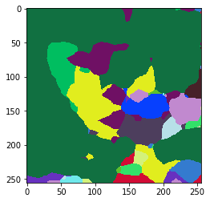

```python
model.eval()
seg, _ = model(testData[10,:,:,:].view(1,testData.shape[1], testData.shape[2], testData.shape[3]).cuda())
showSegmentation(torch.argmax(seg.cpu()[0,:,:,:], dim = 0).numpy())
```

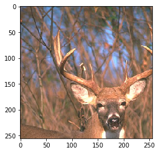

```python
showImage(testData[10,:,:,:])
```

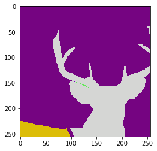

```python
showSegmentation(segmentationsTest[10,:,:].cpu().numpy())
```

You can still see the vague shape, but it looks like we have overfit to the data. This is probably a result of having so few data points in our training set, but given that our results seem to be passable I would rather not risk downloading a bigger dataset (especially since I will be starting the project for this course this month, which will probably require a large dataset). It's also worth noting that the part of the implementation that I ommitted was a regularization factor, so this probably helped the author's model generalize.

### Final Thoughts on Image Segmentation

I think that this was certainly a worth while exercise for me. Not only did I learn about implementing image segmentation, but I also learned how to implement transfer learning, and how to find image gradients using the canny algorithm. I think I improved from last week by spending a substantially longer portion of my time looking at the source code given by the authors which helped me understand this paper to a greater depth than I would normally. There are still differences between my implementation and theirs, but these differences were deliberate rather than the result of me making potentially false assumptions about how the author's implemented their solution. I think I could still improve this (especially with a larger dataset), but it still worked remarkably well given my hardware and data limitations.